# Informe sobre perfil cognitivo y estrategias de aprendizaje

Investigación: Educación en tiempos de COVID

[figure not shown]

# Resultados del participante N°: 1234

## Perfil Memoria de Trabajo

- Recuerdas un nuevo número telefónico, correo electrónico o un número de patente mientras estas tratando de encontrar una lapicera y papel para escribir…
- Estás siguiendo indicaciones verbales…
- Calculas si te alcanzará el dinero mientras compras en el supermercado…
- Midiendo y combinando la cantidad correcta de ingredientes de una receta que acabas de leer…
- Prestas atención a lo que el profesor está diciendo en clase mientras buscas tomar nota de las ideas más relevantes, o bien…
- Tratas de mantener los detalles de la pregunta que hizo el profesor mientras elaboras una respuesta adecuada y completa…

**Tu resultado en memoria de trabajo**: Tu capacidad de memoria de trabajo es muy alta. Esto significa que tienes muy buena habilidad para mantener y manipular información mentalmente (estas por encima del 75% comparado con otros estudiantes universitarios de Argentina). ¡Felicitaciones!

## Perfil Procesamiento Visoespacial

Otro aspecto muy importante de la memoria de trabajo se refiere a la capacidad para procesar información viso-espacial. Esta capacidad la evaluamos cuando tenías que recordar la secuencia de cuadrados de colores mientras debías decidir si una figura era simétrica o asimétrica. Esta capacidad se pone en juego en situaciones como:

- Recordar donde te estacionaste y decidir qué camino tomar hacia ese sitio…
- Hacer un croquis o un mapa mentalmente…
- Decidir donde debería sentarse cada invitado alrededor de una mesa para ocho de forma que se evite sentar juntos a parejas separadas…
- Imaginarte una secuencia de pasos en un plan…
- Tratar de recordar un esquema visual o cuadro sinóptico que preparaste para tu exámen…

En estas y muchas otras situaciones donde tienes que integrar información viso-espacial y tomar decisiones en base a esos datos, se pone en juego en menor o mayor medida tu capacidad de memoria de trabajo viso-espacial.

**Tu resultado en memoria de trabajo visoespacial**: Esta tarea ha sido todo un reto para ti. Cuando tienes que hacerte un mapa mental, planificar visualmente un esquema, o imaginar una secuencia de pasos, puede costarte un mayor esfuerzo que el promedio. Ayúdate de otras estrategias para recordar (tomando notas, escuchando audios, viendo videos o repasando más veces el material).

## Perfil Estrategias de aprendizaje

A continuación verás un perfil de tus estrategias de aprendizaje. Éste fue elaborado en base a tus respuestas al cuestionario sobre tus hábitos de estudio, estrategias de aprendizaje y motivación durante el cursado de las materias online. Las estrategias de aprendizaje en general se refieren a pensamientos, actitudes y conductas que te ayudan a adquirir nueva información e integrarla a tus conocimientos previos. Este perfil te ayudará a conocer mejor tus fortalezas y debilidades en el estudio. Hay que tener en cuenta que las estrategias de aprendizaje aquí evaluadas se pueden aprender y re-entrenar. Para aquellos puntos que presentes más dificultades te sugerimos algunos tips a tener en cuenta.

**Tus resultados en estrategias de aprendizaje y autoregulación**:

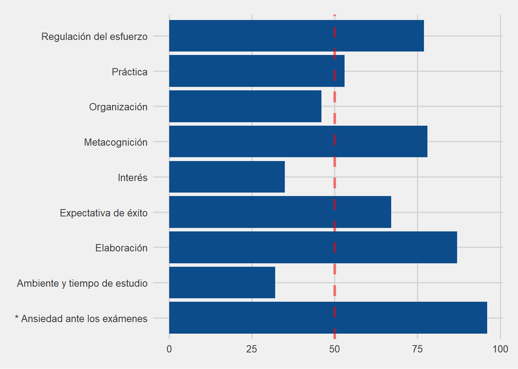

**Descripción de resultados**

*Motivación:*

- **Interés**: 35%. Esta es una medida de cuán interesado estás en las materias que has cursado en modalidad online. Un puntaje superior al 75% indica que te gustaron mucho las materias y estuviste muy interesado en el contenido estudiado.
  - Esta es una estrategia que necesitas mejorar. Puedes seguir alguna de estas recomendaciones: Parafrasea y resume la información más importante. Utiliza tus propias palabras para describir el material cubierto durante el curso o que debes leer. Imagina que eres el profesor tratando de explicar el tema a tus alumnos. Trata de ir relacionando cada tema con los demás temas. Pregúntate, ¿cuáles son las conexiones entre lo que has escuchado en clases o en una discusión y lo leído en los libros?
- **Expectativa de éxito**: 67%. Esta es una medida de tu percepción acerca de las posibilidades de aprobar las materias que cursas online y de tu confianza en comprender el contenido de las mismas. Un puntaje superior a 75% indica que crees que lo puedes hacer muy bien y sientes mucha confianza de que lograrás dominar el material de estudio.
  - Esta es una estrategia que deberías considerar mejorar. Puedes seguir alguna de estas recomendaciones: Trata de evaluar cómo realizas las tareas necesarias para aprender la materia desde diferentes puntos de vista. Por ejemplo, describe cuán efectivo te parece que eres en tu forma de aprender y luego imagina cómo evaluaría esa manera un compañero. Al analizar la forma de encarar una tarea, puedes ser capaz de darte cuenta qué estás haciendo correctamente y en que te estas equivocando a fin de cambiar tu modo de enfrentar la situacion. Una mejor comprensión de la forma en que aprendes, qué funciona y qué no funciona, puede ayudarte a incrementar tu confianza en lo que haces mientras cursas las materias.
- **Ansiedad ante los exámenes**: 96%. Esta es una medida de cuán preocupado estás acerca de los exámenes y cuán a menudo experimentas pensamientos negativos o ansiedad que te distraen mientras realizas un examen. A diferencia de otras escalas, un nivel alto en esta significa que te pones muy ansioso/a ante situaciones de evaluación.
  - *Importante: Ansiedad ante los exámenes, se interpreta de manera inversa. Por lo que a menor ansiedad ante los exámenes, mayores estrategias posees. Esta es una estrategia que necesitas mejorar. Puedes seguir alguna de estas recomendaciones: Está demostrado que desarrollar mejores habilidades de estudio disminuye los niveles de ansiedad. Trata de prepararte bien para las clases y completar las tareas a tiempo, no esperar a último momento para hacer las cosas o prepararte para el examen. Hacer esto ayudará a que te sientas más confiado en el momento del examen y a reducir la ansiedad. Cuando estés dando un examen, concéntrate en una pregunta o problema a la vez. Si encuentras dificultades en una pregunta, continúa y regresa para completarla luego. Recuerdate a ti mismo que te has preparado bien y si no logras responder está bien, aún puedes responder las demás.

*Estrategias de Aprendizaje:*

- **Práctica**: 53%. Esta escala evalúa cuán seguido utilizas estrategias durante el cursado de las materias online, tales como volver a leer tus notas de clases o las lecturas del curso o bien memorizar listas de palabras o conceptos claves. Un puntaje alto indica que las utilizas bastante a menudo.
  - Esta es una estrategia que deberías considerar mejorar. Puedes seguir alguna de estas recomendaciones: Haz una lista de los temas y los términos vistos en la materia. Defínelos y repítelos en voz alta. Distribuye esos términos o conceptos en listas más cortas que incluyan aquellos que están conceptualmente más cercanos o relacionados. Trata de hacerte imágenes con ellos o rimas que te ayuden a recordar las listas. Intercala estudio y revision de lo estudiado para tratar de medir tu propia capacidad de recordarlos y afianzar lo aprendido.
- **Elaboración**: 87%. Esta escala refleja cuán seguido intentas resumir o parafrasear (poner en tus propias palabras) el material que lees de tus clases online, y cuán frecuente tratas de relacionar lo que ya sabías con lo que estás aprendiendo. Un alto puntaje significa que utilizas estas estrategias bastante seguido. Estas estrategias suelen tener un mejor resultado que las estrategias de práctica.
  - Esta es una de estrategias que utilizas frecuentemente, una de tus fortalezas. ¡Continúa así!
- **Organización**: 46%. Esta escala refiere a tu habilidad para seleccionar las ideas principales de lo que lees como así tambien tus intentos de organizar e integrar lo que necesitas aprender de las materias que cursas online.
  - Esta es una estrategia que necesitas mejorar. Puedes seguir alguna de estas recomendaciones: Realiza un índice o esquema de la materia e identifica en qué partes los textos y los temas de clases se superponen y en cuales no se superponen. Esto te dará un punto de partida para establecer conexiones entre las ideas que se te presentaron en ambos contextos. Haz cuadros, diagramas o tablas con los conceptos más importantes. A veces un diagrama de flujo puede ser muy útil para tratar de entender cómo las diferentes ideas se integran.
- **Metacognición**: 78%. Esta es una medida de cuán seguido piensas acerca de lo que estás leyendo o estudiando mientras realizas tus actividades referidas a las materias online. Por ejemplo, ¿monitoreas tu atención mientras lees o encuentras que has leído 10 páginas pero no puedes recordar nada de ellas?, ¿realizas ajustes de tu velocidad de lectura si estás ante un texto difícil comparado con una revista de mas facil lectura? Un alto puntaje significa que tratas de planear tu trabajo y chequear si comprendes lo visto en el curso online.
  - Esta es una de estrategias que utilizas frecuentemente, una de tus fortalezas. ¡Continúa así!
- **Ambiente y tiempo de estudio**: 32%. Esta escala es una medida de cuán bien manejas tus horarios y tu tiempo, así como el uso del lugar de estudio. Un alto puntaje indica que tiene un método para administrar tus horarios y que tratas de estudiar en un lugar favorable para completar tus tareas.
  - Esta es una estrategia que necesitas mejorar. Puedes seguir alguna de estas recomendaciones: Mantén un registro de lo que haces con tu tiempo de estudio durante una semana. Escribe cuáles son tus objetivos para cada período de estudio y luego registra lo que realmente lograste durante el mismo. Analiza estos registros al fin de la semana. Tal vez quieras cambiar el lugar en el que estudias, el tiempo o la persona con la que estudias. Trata de lograr un esquema de horarios que se adapte mejor a vos.
- **Regulación del esfuerzo**: 77%. Esta escala refiere a tu voluntad para realizar esfuerzo en tus tareas y actividades académicas, aún cuando sean difíciles. Un alto puntaje significa que lo intentas con ahínco y pones esfuerzo en tus estudios.
  - Esta es una de estrategias que utilizas frecuentemente, una de tus fortalezas. ¡Continúa así!

## **¡Gracias por haber participado!**

Sigamos conectados. Seguinos en nuestras redes:  
[Linkedin](https://ar.linkedin.com/company/cognitive-icrc)  
[Facebook](https://www.facebook.com/permalink.php?id=101193491706272&story_fbid=133982445094043)  
[ResearchGate](https://www.researchgate.net/lab/International-Cognitive-Research-Consortium-Mariel-Musso)

Código fuente disponible [aquí](https://github.com/JulietaNieva).